# Using the sprintr package

Guo Yu

```r
library(sprintr)
```

The `sprintr` package contains the implementations of a computationally efficient method, called sprinter, to fit large interaction models based on the reluctant interaction selection principle. The details of the method can be found in [Yu, Bien, and Tibshirani (2021) *Reluctant interaction modeling*](https://arxiv.org/abs/1907.08414). In particular, `sprinter` is a multi-stage method that fits the following pairwise interaction model:
$$y = \sum_{j = 1}^p X_j \beta^\ast_j + \sum_{\ell \leq k} X_{\ell} X_k \gamma^\ast_{\ell k} + \varepsilon.$$
This document serves as an introduction of using the package with a simple simulated data example.

## Data simulation

We consider the following simple simulation setting, where $X \sim N(\mathbf{0}, \mathbf{I}_p)$. There are two non-trivial main effects $\beta_1 = 1$, $\beta_2 = -2$, and $\beta_j = 0$ for $j > 2$. The two important interactions are $X_1 * X_3$ with $\gamma_{13} = 3$, and $X_4 * X_5$ with $\gamma_{45} = -4$. With $\varepsilon \sim N(0, 1)$, the following code simulates $n = 100$ observation from the model above with $p = 100$.

```r
library(sprintr)
set.seed(123)
n <- 100
p <- 100
x <- matrix(data = rnorm(n * p), nrow = n, ncol = p)
y <- x[, 1] - 2 * x[, 2] + 3 * x[, 1] * x[, 3] - 4 * x[, 4] * x[, 5] + rnorm(100)
```

# Using `sprinter` function

The function `sprinter` implements the sprinter method (please note that the function name `sprinter` is different from the package name `sprintr`), which involves the following three main steps:

- Fit a lasso (over a path of $\lambda_1$ values) of the response $y$ only on main effects $X$ (if `square = FALSE` by default) or with both main effects and squared effects $(X, X^2)$ (if `square = TRUE`). Denote the residual as $r_{\lambda_1}$.
- Carry out a screening procedure based on the residual from the previous step. The number of the selected candidate interactions can be specified by a path of `num_keep` values.
- With a path of tuning parameter $\lambda_2$ values, fit a lasso of the residual $r_{\lambda_1}$ on main effects, squared effects (if `square = TRUE`), and selected interactions from the previous step.

Finally, a `verbose` option (default to be `TRUE`) can be turned on to see the progress of the computation.

```r
fit <- sprinter(x = x, y = y, square = FALSE)
```

## `sprinter` output

The output of `sprinter` is a `S3` object including several useful components. The major components are `step1`, `step2`, and `step3`. `step1` includes the `glmnet` fit with tuning `lambda1`. The component `step 2` is a list of length `nlam1`, with `step2[[j]]` containing information about the selected interactions in Step 2 with the residual from Step 1 with tuning parameter `lambda1[j]`. The component `lambda1` is the path of tuning parameters used in Step 1. And `lambda3` is a matrix, with `lambda3[, j]` representing the path of tuning parameters used in Step 3 when Step 1 uses `lambda1[j]` as the tuning parameter.

```r
fit$step2[[1]]
```

```
#>       index_1 index_2    score
#>  [1,]       4       5 421.3423
#>  [2,]       1       3 320.1576
#>  [3,]       4      96 294.3083
#>  [4,]       5      25 234.5844
#>  [5,]      95      96 224.6897
#>  [6,]      17      77 219.1827
#>  [7,]      29      95 218.0110
#>  [8,]       4      29 210.3960
#>  [9,]      76      77 209.5497
#> [10,]       5      97 205.7667
#> [11,]      43      49 202.0683
#> [12,]       4      57 195.3419
#> [13,]       4      78 195.2760
#> [14,]       3      82 192.4835
#> [15,]      96      97 192.2015
#> [16,]      46      77 191.2056
#> [17,]       1      76 190.6634
#> [18,]       4      72 185.8181
#> [19,]      13      30 183.3793
#> [20,]       8      43 182.8605
#> [21,]       1      87 181.5040
#> [22,]      13      99 181.0824
```

In particular, each element of `step2` contains the indices of all the selected interactions, and the last column represents the corresponding scores used for selection in Step 2.

The component `step3` is a list of length `nlam1`, with `step3[[j]]` containing information from Step 3 fit when the tuning parameter in Step 1 is `lambda1[j]`. Specifically, the output `fit3[[j]]$coef` is a `nrow(fit$step2[[j]]) + p`-by-`length(fit$lambda3)` matrix. Each column of `fit3[[j]]$coef` is a vector of estimates of all variable coefficients (`p` main effects + `nrow(fit$step2[[j]]` selected interactions) considered in Step 3 corresponding to the glmnet fit with one tuning parameter in `lambda3[, j]`. For example, for the 4-th tuning parameter in Step 1 and the 30-th tuning parameter of Step 3, we have the corresponding coefficient estimate:

```r
estimate <- fit$step3[[4]]$coef[, 30]
```

## Cross-validating Step 1 before subsequent steps

To facilitate efficient computation, we provide the option to conduct cross-validation in Step 1 before proceeding to Step 2 and Step 3 as described in Section 3.1 in the paper. This functionality can be turned on using `cv_step1 = TRUE` argument:

```r
fit_cvstep1 <- sprinter(x = x, y = y, square = FALSE, cv_step1 = TRUE)
```

The output remains in the same format, with the only difference that only the result corresponding to the CV-selected value in Step 1 is reported.

## Summarizing `sprinter` output by `print` and `plot`

The output of `sprinter` has an associated `print` function, that prints information (the number of nonzero main effects and nonzero interactions) of Step 3 fits along a path (column) of `lambda3`, for a given value of Step 1 tuning parameter (specified by `which`). For example, the following codes prints the output when the 2nd value of Step-1 tuning parameter is used:

```r
print(fit, which = 2)
```

```
#>
#> Call:  sprinter(x = x, y = y, square = FALSE)
#>
#>           lambda #nz main #nz interaction
#>   [1,] 3.5830000        0               0
#>   [2,] 3.2640000        0               1
#>   [3,] 2.9740000        0               1
#>   [4,] 2.7100000        0               1
#>   [5,] 2.4690000        0               2
#>   [6,] 2.2500000        0               2
#>   [7,] 2.0500000        0               2
#>   [8,] 1.8680000        0               2
#>   [9,] 1.7020000        0               2
#>  [10,] 1.5510000        0               2
#>  [11,] 1.4130000        0               2
```

[output cut: 89 more lines]

Furthermore, `plot` function shows the dependence of coefficient estimates for each main effects (left panel) and interactions(right panel) on the Step-3 tuning parameters for a particular value of `lambda1` (specified by `which`):

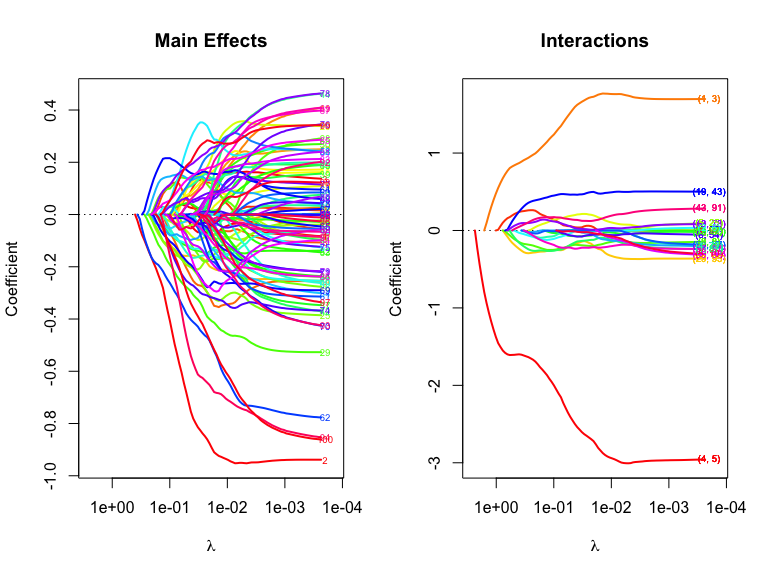

```r
plot(fit, which = 3)
```

# Using cross-validation with `cv.sprinter`

The function `cv.sprinter()` performs a 2-dimensional cross-validation to select the best value pair of `lambda1` (if `cv_step1 == FALSE`) and `lambda3`. If `cv_step1 == TRUE`, then `cv.sprinter()` only performs a 1-dimensional CV to select best value of `lambda3` when Step 1 uses the CV selected `lambda1`.

```r
fit_cv <- cv.sprinter(x = x, y = y, square = FALSE)
```

## `cv.sprinter` output

The output of `cv.sprinter` is a `S3` object. Please refer to the help document for more detailed description of the output components. The most interesting information is `fit_cv$compact`, which is a matrix of three columns. The first two columns show the indices pairs of all variables finally selected by cross-validation, and the last column is the coefficient estimate corresponding to those selected variables.

```r
fit_cv$compact
```

```
#>       index_1 index_2  coefficient
#>  [1,]       0       1  1.338539719
#>  [2,]       0       2 -1.856859127
#>  [3,]       0       3  0.094322730
#>  [4,]       0       4 -0.392598879
#>  [5,]       0      13 -0.020814947
#>  [6,]       0      15  0.023568197
#>  [7,]       0      20  0.014210444
#>  [8,]       0      21  0.019829941
#>  [9,]       0      25 -0.073971452
#> [10,]       0      31 -0.032587012
#> [11,]       0      34 -0.102719234
#> [12,]       0      35  0.044691171
#> [13,]       0      38 -0.076747981
#> [14,]       0      39 -0.117843688
```

[output cut: 26 more lines]

We see (from the first two rows and the last two rows) that the fit selected by cross-validation includes all the four important variables ($X_1, X_2, X_4*X_5, X_1 * X_3$) in the model, with relatively accurate estimates of their coefficients.

## Summarizing `cv.sprinter` output by `print` and `plot`

Associated with the output of `cv.sprinter` are the `print` and `plot` functions. `print` functions can be used to the summary of the cross-validation process, indicating information such as the best number of candidate interactions in Step 2, and the validation error mean/standard errors, number of non-zero main effects/interactions for the Step-3 tuning parameter selected by `min` rule and `1se` rule.

```r
print(fit_cv)
```

```
#>
#> Call:  cv.sprinter(x = x, y = y, square = FALSE)
#>
#>      lambda1 lambda3 mean(vali-err) se(vali-err) #nonzero-main #nonzero-inter
#> [1,]   2.126 0.07714          1.847       0.6225            27             13
```

The `plot` function for the output of `cv.sprinter` shows the validation error across different folds as a function of Step-3 tuning parameters (for a fixed value of Step-1 tuning parameter chosen by cross-validation). The top of the plot shows the number of nonzero main effects / nonzero interactions corresponding (in orange) to a value of Step-3 tuning parameters.

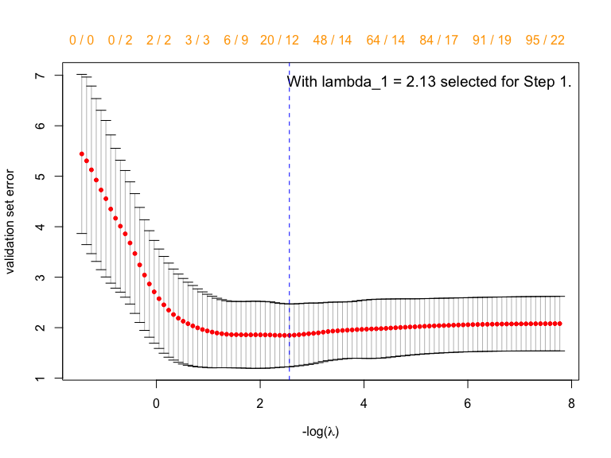

```r
plot(fit_cv)
```

The blue vertical line shows the Step-3 tuning parameter selected by CV that minimizes `cvm`.

# Prediction

The `predict` function is defined for both the object returned by `sprinter` and `cv.sprinter` that computes the prediction for a new data matrix of main effects:

```r
newdata <- matrix(rnorm(20 * p), nrow = 20, ncol = p)
pred <- predict(fit, newdata = newdata)
```

The prediction for `sprinter` object computes the prediction at `newdata` for all the (Step-1, Step-3) tuning parameter pairs, and the prediction for `cv.sprinter` object just computes the prediction at `newdata` for the best tuning parameter pairs selected by cross-validation.

```r
pred_cv <- predict(fit_cv, newdata = newdata)
```

# Update

## Additional support for `glmnet` function

We allow additional arguments to be passed to `glmnet` call in `sprinter` and `cv.sprinter` by using the `...` argument.